# RStudio intro and tips

Mariana Montes

2025-06-26

## Outline

- Projects
- Panes
- Settings
- Add-ins

**Tip**

Slides and examples available at github.com/montesmariana/rstudio-intro

# Projects

## Projects: what?

- Folders with an .Rproject file inside.
- They can be a git repository at the same time.
- Easy to open and manage in R Studio

## Encapsultation

**Tip**

Keep your code, its inputs and outputs, its docs, all together.

- Open different projects in different windows without them interacting with each other.
- Reopening a project in RStudio can keep the same files open.
- The root of the project is the root of the file explorer.

## Reproducibility

**Tip**

Let a set of data and code to move around together, so that others can run it or you can run it somewhere else.

- With `{here}`, use paths relative to the root of the project, independent of where the project lives in a particular computer.
- In non-HPC systems, `{renv}` is a good way of keeping track of the packages for a certain project and their versions.

# Panes

## Panes

- Source, eventually dataframe views
- **Console**, terminal, background jobs
- History, environment, packages, git…
- Files, plots, help, tutorials (for `{learnr}`), viewer, presentation

**Tip**

The order and organization can be changed in Tools > Global options

## Terminal

**What for?**

For bash operations, for users with terminal experience.

- For git, users with little experience may prefer the GUI in the other panel
- For file manipulation, users might prefer the file explorer

## History

**What?**

What has happened in the console

- Recommendation: uncheck “Always save history”.
- If someone comes to you with mysterious problems, the first step to reproduce is to restart the session with a clean history (and environment)

## Environment

**What?**

Available variables and functions in the global environment.

- Recommendation: uncheck “Restore .Rdata into workspace”

## Console

**What for?**

Interactive typing of code and where code that is run shows up.

- You can go up the history
- Unhandy for multiple lines - clean with Ctrl + L
- It won’t survive across sessions.
- Very handy for exploring the use of functions, the content of variables (things that print and that don’t need/have to be in scripts)

## Help: what and how

- where you can see the documentation of functions.
- You can search for a function in a search box, or more typically by typing `?` and the function:
  - `?print` for usage of the base `print` function
  - `?stringr::str_count` or `?str_count` if the package was loaded

## Help: Package documentation

- R functions are typically very thoroughly documented, but older (e.g. base) documentation is often quite cryptic.
- Tidyverse functions have very nice documentation, vignettes, examples…
  - These functions also tend to have prefixes for each package (for autocomplete and searching)
- Packages with datasets also document the datasets!

## Plots: what

- If you plot something interactively (unlike Figure 1) it will show up in this panel

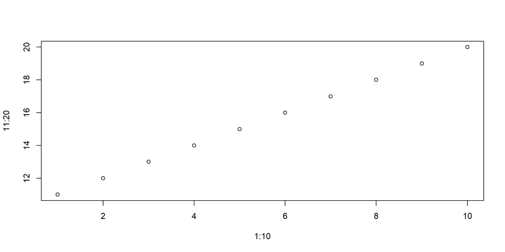

Figure 1: A plot in a document

## Plots: packages

- The base `plot()` will render it in whatever size the panel has, so you may get an error if the panel is too small: `Error in plot.new(): figure margins too large`.
- `ggplot2::ggplot()` and family won’t care about the size of the panel, and you can resize it after rendering without errors.

## Source

**What?**

Where you write your source code, but also view any other plain text file.

- Open a dataframe in this panel:
  - `View(variable)`
  - Clicking on the variable in Environment
- Other files you can view: plain text, markdown (and Rmd, qmd…), python…

## Source: keyboard shortcuts

- Ctrl+F to search for things in a file.
- Ctrl+Shift+F to search in a *project*.
- Ctrl+F7 to open an extra source panel

## Source: R files

- Ctrl+Shift+C (or appropriate character) to (un)comment
- Alt+- for the assignment operator `<-`
- Ctrl+Shift+M for the pipe `|>` (or `%>%`)
- Ctrl+Enter to run and go to next line/block
- Automatic outline and sections: hierarchical comments with `# Heading ####`
  - More `#` at the beginning increase level
  - At least four `#`, `=` or `-` at the end
- Inline debugger

# Settings

## Tools > Global options

- Graphic engine (e.g. agg for emojis in plots 😊)
- Appearance
- Pipe operator! (Native: `|>` vs magrittr (`%>%`)
- Git (e.g. SSH key)
- (Not) storing history and data

# Add-ins

## Some packages with add-ins

- `{todor}` for comments with “TODO” and stuff to keep track of notes
- `{reprex}` to generate reproducible examples
- `{learnr}` fills in the Tutorial tab